# RHESSysIOinR_Coweeta_WS32_74 Multi Site Validation Field Data_Step2

Carlos Quintero

5/24/2024

Coweeta Hydrologic Laboratory Watershed 32 using Static, SSURGO, and RSS soil inputs.

The following R Markdown script prepares and runs the Regional Hydro-Ecologic Simulation System (RHESSYS) within the R environment. Modified from RHESSysIOinR example scripts created by Will Burke and Ryan Bart. Includes CLHS code snippets and SDA code from Dylan Beaudette.

Windows Subsystem via Linux must be installed before RHESSys will run in a Windows environment. GRASS8 must be installed to run the spatial preprocessing portion of the script.

Code has been modified to run RHESSys 7.4 and 5.18. 7.4 vegetation processing differs slightly from 5.18. Various template differences exist between the two versions of RHESSys and template files must be carefully reviewed if moving between versions. This script is currently set up to run RHESSys 7.4

```r
knitr::opts_chunk$set(warning = FALSE, message = FALSE)
#install.packages("devtools")
#devtools::install_github("ropensci/FedData")

library(aqp)
library(daymetr)
library(clhs)
library(EcoHydRology)
```

```r
library(elevatr)
library(ezknitr)
#library(FedData)
library(foreach)
library(foreign)
library(ggplot2)
library(ggpubr)
library(hydroGOF)
library(imputeTS)
library(knitr)
library(latticeExtra)
library(lubridate)
library(Metrics)
library(raster)
library(rasterVis)
library(readxl)
library(reshape2)
library(rgdal)
library(rgrass)
```

[output not shown]

```
## GRASS GIS interface loaded with GRASS version: sh: line 1: g.version: command not found
## and location: Coweeta3
```

```r
library(rmarkdown)
library(Rmisc)
library(RHESSysPreprocessing)
library(RHESSysIOinR)
library(sf)
library(soilDB)
library(sp)
library(stats)
library(stringi)
library(tactile)
library(terra)
library(testthat)
library(tidyverse)
library(viridisLite)
library(dplyr)

setwd(system.file("extdata/", package = "RHESSysIOinR"))
getwd()
```

```
## [1] "C:/Users/Carlos/Documents/R/win-library/4.0/RHESSysIOinR/extdata"
```

```r
rh_ver = dir(path = "modelfiles/rhessys/", pattern = "^rhessys\\d+",recursive = F)
rh_path = file.path("modelfiles/rhessys", rh_ver)

## Load in necessary files
filedir <- ("C:/Users/Carlos/Documents/GitHub/RHESSys74-R-Markdown/")

watershedshapefile <- paste0(filedir, "input_files/shapefiles/watersheds/Coweeta_Hydrologic_Laboratory.shp")
streamshapefile<- paste0(filedir,"input_files/shapefiles/streams/StreamsCaldwellClipped.shp")
weirshapefile<- paste0(filedir,"input_files/shapefiles/weirs/Subbasinoutlets.shp")
roadshapefile <- paste0(filedir, "input_files/shapefiles/roads/UpdatedRoads4Reprojected32617.shp")

CWRG12 <- paste0(filedir,"input_files/precipitation/RDS-2017-0031/Data/RG12_daily_1942_2021.csv")
CWRG20 <-paste0(filedir,"input_files/precipitation/RDS-2017-0031/Data/RG20_daily_1962_2021.csv")

CS21<- paste0(filedir,"input_files/temperature/RDS-2015-0042/Data/cs21_daily.csv")
CS28<- paste0(filedir,"input_files/temperature/RDS-2015-0042/Data/cs28_daily.csv")

newsmlocations<-  paste0(filedir,"input_files/shapefiles/soil_moisture/CoweetaNRCSsmKML.kml")
```

Setup RHESSys Inputs/Outputs for Spinup Note that flowtable is converted flowtable. Using original flow table will result in errors.

```r
setwd(system.file("extdata/", package = "RHESSysIOinR"))
## Read climate file to see length available climate data
read_clim("clim/cwtws32extended.rain", dates_out=TRUE)
```

```
## [1] "1734 01 26 01" "2021 12 31 24"
```

```r
read_clim("clim/cwtws32local.rain", dates_out=TRUE)
```

```
## [1] "1990 01 04 01" "2021 12 31 24"
```

```r
input_rhessys = IOin_rhessys_input(
  version = rh_path,
  tec_file = "tecfiles/tec_daily",
  world_file = "CWWS32static.world",
  world_hdr_prefix = "CWWS32static",
  flowtable = "CWWS32.flow",
  start = "1775 11 1 1",
  end = "2018 11 2 1",
  output_folder = "out",
  output_prefix = "cwws32",
  commandline_options = c("-b -g"))

input_tec_data = IOin_tec_std(start = "2015 11 1 1",
                              end = "2018 11 1 1",
                              output_state = TRUE)

input_hdr = IOin_hdr(
  basin = "defs/basin.def",
  hillslope = "defs/hillslope.def",
  zone = "defs/zone.def",
  soil = c("defs/soil_clay.def","defs/soil_clayloam.def","defs/soil_loam.def","defs/soil_loamysand.def","defs/soil_rock.def","defs/soil_sand.def","defs/soil_sandyclay.def","defs/soil_sandyclayloam.def","defs/soil_sandyloam.def","defs/soil_silt.def","defs/soil_siltyclay.def","defs/soil_siltyclayloam.def","defs/soil_siltyloam.def","defs/soil_water.def", "defs/soil_shallowloam.def", "defs/soil_shallowsandyclayloam.def", "defs/soil_shallowsandyloam.def"),
  landuse = "defs/lu_undev.def",
  stratum = c("defs/veg_deciduous/veg_deciduous.def","defs/veg_evergreen/veg_evergreen.def","defs/veg_deciduous_BES.def","defs/veg_eucalypt.def","defs/veg_grass.def","defs/veg_lawn_2cm.def","defs/veg_lawn_5cm.def","defs/veg_lawn_10cm.def","defs/veg_nonveg.def"),
  basestations = "clim/cwtws32extended.base")

##suggested standard hydrologic spinup parameters from rhessys wiki, gw values modified based on previous results from Coweeta Landscape

stdpars<- IOin_cmd_pars(
            m = 1,
            k = 10,
            soil_dep= 0.4,
            m_v = 1,
            k_v = 1,
            gw1 = 0.15,
            gw2 = 0.35)
```

Run Spinup #1 Spinup runs model on one processor for x number of years. Takes a very long time. Spinup has been turned off for the purposes of this demonstration. Using previously spun up file ~ 12 hours, run multiple times.

Run Spinup again, Run Spinup #2

Read Spinup and confirm that Soil C and Soil N have stabilized

```r
setwd(system.file("extdata/", package = "RHESSysIOinR"))
spinupoutput<- readin_rhessys_output("out/CWWS32_runspinup")

#spinupoutput<- readin_rhessys_output("out/cwws32dsm_rundsmspinup")
#spinupoutput<- readin_rhessys_output("out/cwws32ssurgo_runssurgospinup")

spinupoutput$bd$date <- make_date(year=spinupoutput$bd$year, month = spinupoutput$bd$month, day = spinupoutput$bd$day)
spinupoutput$bdg$date <- make_date(year=spinupoutput$bdg$year, month = spinupoutput$bdg$month, day = spinupoutput$bdg$day)

range(spinupoutput$bd$year)
```

```
## [1] 2015 2018
```

```r
plot(spinupoutput$bd$streamflow, type = "l")
```

[output not shown]

```r
plot(spinupoutput$bd$date,spinupoutput$bd$streamflow, type = "l", col = 'black', main = "Predicted Streamflow",
    xlab = "Date", ylab = "Streamflow mm")
```

[output not shown]

```r
plot(spinupoutput$bdg$date, spinupoutput$bdg$lai, type = "l", main = "LAI", xlab = "Date")
```

[output not shown]

```r
{plot(spinupoutput$bdg$soilc~spinupoutput$bdg$date,type = "l", main = "Spinup Soil Carbon", xlab = "Date")
soilctrend <- glm(spinupoutput$bdg$soilc~spinupoutput$bdg$date)
abline(soilctrend, col = 'red')}
```

[output not shown]

```r
{plot(spinupoutput$bdg$date,spinupoutput$bdg$soiln, type = "l", main = "Spinup Soil Nitrogen", xlab = "Date")
soilntrend <- glm(spinupoutput$bdg$soiln~spinupoutput$bdg$date)
abline(soilntrend , col = 'green')}
```

[output not shown]

##spinupssurgo

```r
setwd(system.file("extdata/", package = "RHESSysIOinR"))
## Read climate file to see length available climate data
read_clim("clim/cwtws32extended.rain", dates_out=TRUE)
```

```
## [1] "1734 01 26 01" "2021 12 31 24"
```

```r
read_clim("clim/cwtws32local.rain", dates_out=TRUE)
```

```
## [1] "1990 01 04 01" "2021 12 31 24"
```

```r
input_rhessys = IOin_rhessys_input(
  version = rh_path,
  tec_file = "tecfiles/tec_daily",
  world_file = "CWWS32ssurgo.world",
  world_hdr_prefix = "CWWS32ssurgo",
  flowtable = "CWWS32ssurgo.flow",
  start = "1775 11 1 1",
  end = "2018 11 2 1",
  output_folder = "out",
  output_prefix = "cwws32",
  commandline_options = c("-b -g"))

input_tec_data = IOin_tec_std(start = "2015 11 1 1",
                              end = "2018 11 1 1",
                              output_state = TRUE)

input_hdr = IOin_hdr(
  basin = "defs/basin.def",
  hillslope = "defs/hillslope.def",
  zone = "defs/zone.def",
  soil = c("defs/soil_clay.def","defs/soil_clayloam.def","defs/soil_loam.def","defs/soil_loamysand.def","defs/soil_rock.def","defs/soil_sand.def","defs/soil_sandyclay.def","defs/soil_sandyclayloam.def","defs/soil_sandyloam.def","defs/soil_silt.def","defs/soil_siltyclay.def","defs/soil_siltyclayloam.def","defs/soil_siltyloam.def","defs/soil_water.def", "defs/soil_shallowloam.def", "defs/soil_shallowsandyclayloam.def", "defs/soil_shallowsandyloam.def"),
  landuse = "defs/lu_undev.def",
  stratum = c("defs/veg_deciduous/veg_deciduous.def","defs/veg_evergreen/veg_evergreen.def","defs/veg_deciduous_BES.def","defs/veg_eucalypt.def","defs/veg_grass.def","defs/veg_lawn_2cm.def","defs/veg_lawn_5cm.def","defs/veg_lawn_10cm.def","defs/veg_nonveg.def"),
  basestations = "clim/cwtws32extended.base")

##suggested standard hydrologic spinup parameters from rhessys wiki, gw values modified based on previous results from Coweeta Landscape

stdpars<- IOin_cmd_pars(
            m = 1,
            k = 10,
            soil_dep= 0.4,
            m_v = 1,
            k_v = 1,
            gw1 = 0.15,
            gw2 = 0.35)
```

Run Spinup #1 and #2 Spinup runs model on one processor for x number of years. Takes a very long time. Spinup has been turned off for the purposes of this demonstration. Using previously spun up file ~ 12 hours, run multiple times.

```r
setwd(system.file("extdata/", package = "RHESSysIOinR"))
spinupoutput<- readin_rhessys_output("out/CWWS32_runspinup")

#spinupoutput<- readin_rhessys_output("out/cwws32dsm_rundsmspinup")
#spinupoutput<- readin_rhessys_output("out/cwws32ssurgo_runssurgospinup")

spinupoutput$bd$date <- make_date(year=spinupoutput$bd$year, month = spinupoutput$bd$month, day = spinupoutput$bd$day)
spinupoutput$bdg$date <- make_date(year=spinupoutput$bdg$year, month = spinupoutput$bdg$month, day = spinupoutput$bdg$day)

range(spinupoutput$bd$year)
```

```
## [1] 2015 2018
```

```r
plot(spinupoutput$bd$streamflow, type = "l")
```

[output not shown]

```r
plot(spinupoutput$bd$date,spinupoutput$bd$streamflow, type = "l", col = 'black', main = "Predicted Streamflow",
    xlab = "Date", ylab = "Streamflow mm")
```

[output not shown]

```r
plot(spinupoutput$bdg$date, spinupoutput$bdg$lai, type = "l", main = "LAI", xlab = "Date")
```

[output not shown]

```r
{plot(spinupoutput$bdg$soilc~spinupoutput$bdg$date,type = "l", main = "Spinup Soil Carbon", xlab = "Date")
soilctrend <- glm(spinupoutput$bdg$soilc~spinupoutput$bdg$date)
abline(soilctrend, col = 'red')}
```

[output not shown]

```r
{plot(spinupoutput$bdg$date,spinupoutput$bdg$soiln, type = "l", main = "Spinup Soil Nitrogen", xlab = "Date")
soilntrend <- glm(spinupoutput$bdg$soiln~spinupoutput$bdg$date)
abline(soilntrend , col = 'green')}
```

[output not shown]

##spinupssurgo

##spinupdsm

```r
setwd(system.file("extdata/", package = "RHESSysIOinR"))
## Read climate file to see length available climate data
read_clim("clim/cwtws32extended.rain", dates_out=TRUE)
```

```
## [1] "1734 01 26 01" "2021 12 31 24"
```

```r
read_clim("clim/cwtws32local.rain", dates_out=TRUE)
```

```
## [1] "1990 01 04 01" "2021 12 31 24"
```

```r
input_rhessys = IOin_rhessys_input(
  version = rh_path,
  tec_file = "tecfiles/tec_daily",
  world_file = "CWWS32dsm.world",
  world_hdr_prefix = "cwws32dsm",
  flowtable = "cwws32dsm.flow",
  start = "1775 11 1 1",
  end = "2018 11 2 1",
  output_folder = "out",
  output_prefix = "cwws32",
  commandline_options = c("-b -g"))

input_tec_data = IOin_tec_std(start = "2015 11 1 1",
                              end = "2018 11 1 1",
                              output_state = TRUE)

input_hdr = IOin_hdr(
  basin = "defs/basin.def",
  hillslope = "defs/hillslope.def",
  zone = "defs/zone.def",
  soil = c("defs/soil_clay.def","defs/soil_clayloam.def","defs/soil_loam.def","defs/soil_loamysand.def","defs/soil_rock.def","defs/soil_sand.def","defs/soil_sandyclay.def","defs/soil_sandyclayloam.def","defs/soil_sandyloam.def","defs/soil_silt.def","defs/soil_siltyclay.def","defs/soil_siltyclayloam.def","defs/soil_siltyloam.def","defs/soil_water.def", "defs/soil_shallowloam.def", "defs/soil_shallowsandyclayloam.def", "defs/soil_shallowsandyloam.def"),
  landuse = "defs/lu_undev.def",
  stratum = c("defs/veg_deciduous/veg_deciduous.def","defs/veg_evergreen/veg_evergreen.def","defs/veg_deciduous_BES.def","defs/veg_eucalypt.def","defs/veg_grass.def","defs/veg_lawn_2cm.def","defs/veg_lawn_5cm.def","defs/veg_lawn_10cm.def","defs/veg_nonveg.def"),
  basestations = "clim/cwtws32extended.base")

##suggested standard hydrologic spinup parameters from rhessys wiki, gw values modified based on previous results from Coweeta Landscape

stdpars<- IOin_cmd_pars(
            m = 1,
            k = 10,
            soil_dep= 0.4,
            m_v = 1,
            k_v = 1,
            gw1 = 0.15,
            gw2 = 0.35)
```

Run Spinup #1 and #2 Spinup runs model on one processor for x number of years. Takes a very long time. Spinup has been turned off for the purposes of this demonstration. Using previously spun up file ~ 12 hours, run multiple times.

```r
setwd(system.file("extdata/", package = "RHESSysIOinR"))
spinupoutput<- readin_rhessys_output("out/CWWS32_runspinup")

#spinupoutput<- readin_rhessys_output("out/cwws32dsm_rundsmspinup")
#spinupoutput<- readin_rhessys_output("out/cwws32ssurgo_runssurgospinup")

spinupoutput$bd$date <- make_date(year=spinupoutput$bd$year, month = spinupoutput$bd$month, day = spinupoutput$bd$day)
spinupoutput$bdg$date <- make_date(year=spinupoutput$bdg$year, month = spinupoutput$bdg$month, day = spinupoutput$bdg$day)

range(spinupoutput$bd$year)
```

```
## [1] 2015 2018
```

```r
plot(spinupoutput$bd$streamflow, type = "l")
```

[output not shown]

```r
plot(spinupoutput$bd$date,spinupoutput$bd$streamflow, type = "l", col = 'black', main = "Predicted Streamflow",
    xlab = "Date", ylab = "Streamflow mm")
```

[output not shown]

```r
plot(spinupoutput$bdg$date, spinupoutput$bdg$lai, type = "l", main = "LAI", xlab = "Date")
```

[output not shown]

```r
{plot(spinupoutput$bdg$soilc~spinupoutput$bdg$date,type = "l", main = "Spinup Soil Carbon", xlab = "Date")
soilctrend <- glm(spinupoutput$bdg$soilc~spinupoutput$bdg$date)
abline(soilctrend, col = 'red')}
```

[output not shown]

```r
{plot(spinupoutput$bdg$date,spinupoutput$bdg$soiln, type = "l", main = "Spinup Soil Nitrogen", xlab = "Date")
soilntrend <- glm(spinupoutput$bdg$soiln~spinupoutput$bdg$date)
abline(soilntrend , col = 'green')}
```

[output not shown]

##spinupsdsm

Configure RHESSys Inputs/Outputs for a single run.

Use World Statefile created during spin-up. To run model one time at patch scale.

COMMAND LINE OPTIONS

-b Basin output option. Print out response variables for specified basins. -c Canopy stratum output option. Print out response variables for specified strata. -g Grow option. Try to read in dynamic bgc input data and output dynamic bgc parameters. -h Hillslope output option. Print out response variables for specified hillslopes. -p Patch output option. Print out response variables for specified patches. -r Routing option. Gives name of flow_table to define explicit routing connectivity. Also trigger use of explicit routing over TOPMODEL approach. -c Stratum output option. Print out response variables for specified strata.

```r
setwd(system.file("extdata/", package = "RHESSysIOinR"))
read_clim("clim/cwtws32daymet.rain", dates_out = TRUE)
```

```
## [1] "1980 01 01 01" "2021 12 31 24"
```

```r
input_rhessys = IOin_rhessys_input(
  version = rh_path,
  tec_file = "tecfiles/tec_daily",
  world_file = "CWWS32.world.Y2018M11D1H1.state.Y2018M11D1H1.state",
  world_hdr_prefix = "CWWS32",
  flowtable = "CWWS32.flow",
  start = "2014 11 1 1",
  end = "2018 11 2 1",
  output_folder = "out",
  output_prefix = "cwws32",
  commandline_options = c("-b -p"))

## TEC file dictates model output, begin output a year in to allow model SM to stabilize
# do not output_state or worldfile may be overwritten as output is created

input_tec_data = IOin_tec_std(start = "2015 11 1 1",
                              end = "2018 11 1 1",
                              output_state = FALSE)

input_hdr = IOin_hdr(
  basin = "defs/basin.def",
  hillslope = "defs/hillslope.def",
  zone = "defs/zone.def",
  soil = c("defs/soil_clay.def","defs/soil_clayloam.def","defs/soil_loam.def","defs/soil_loamysand.def","defs/soil_rock.def","defs/soil_sand.def","defs/soil_sandyclay.def","defs/soil_sandyclayloam.def","defs/soil_sandyloam.def","defs/soil_silt.def","defs/soil_siltyclay.def","defs/soil_siltyclayloam.def","defs/soil_siltyloam.def","defs/soil_water.def", "defs/soil_shallowloam.def", "defs/soil_shallowsandyclayloam.def", "defs/soil_shallowsandyloam.def"),
  landuse = "defs/lu_undev.def",
  stratum = c("defs/veg_deciduous/veg_deciduous.def","defs/veg_evergreen/veg_evergreen.def","defs/veg_deciduous_BES.def","defs/veg_eucalypt.def","defs/veg_grass.def","defs/veg_lawn_2cm.def","defs/veg_lawn_5cm.def","defs/veg_lawn_10cm.def","defs/veg_nonveg.def"),
  basestations = "clim/cwtws32local.base")

stdpars<- IOin_cmd_pars(
            m = 1.75,
            k = 18.69,
            soil_dep= 0.48,
            m_v = 2.55,
            k_v = 7.54,
            gw1 = 0.19,
            gw2 = 0.29,
            pa = 0.17,
            po = 1.02,
            vgseng1 = 1.61,
            vgseng2 = 1.94,
            vgseng3 = 0.72)
```

Run RHESSys once

Run RHESSys once with output filter

```r
setwd(system.file("extdata/", package = "RHESSysIOinR"))

input_rhessys = IOin_rhessys_input(
  version = rh_path,
  tec_file = "tecfiles/tec_daily",
  world_file = "CWWS32.world.Y2018M11D1H1.state.Y2018M11D1H1.state",
  world_hdr_prefix = "CWWS32",
  flowtable = "CWWS32.flow",
  start = "2014 11 1 1",
  end = "2018 11 1 1",
  output_folder = "out",
  output_prefix = "cwws32",
  commandline_options = c())

input_tec_data = IOin_tec_std(start = "2015 11 1 1",
                              end = "2018 11 1 1",
                              output_state = FALSE)

input_hdr = IOin_hdr(
  basin = "defs/basin.def",
  hillslope = "defs/hillslope.def",
  zone = "defs/zone.def",
  soil = c("defs/soil_clay.def","defs/soil_clayloam.def","defs/soil_loam.def","defs/soil_loamysand.def","defs/soil_rock.def","defs/soil_sand.def","defs/soil_sandyclay.def","defs/soil_sandyclayloam.def","defs/soil_sandyloam.def","defs/soil_silt.def","defs/soil_siltyclay.def","defs/soil_siltyclayloam.def","defs/soil_siltyloam.def","defs/soil_water.def", "defs/soil_shallowloam.def", "defs/soil_shallowsandyclayloam.def", "defs/soil_shallowsandyloam.def"),
  landuse = "defs/lu_undev.def",
  stratum = c("defs/veg_deciduous/veg_deciduous.def","defs/veg_evergreen/veg_evergreen.def","defs/veg_deciduous_BES.def","defs/veg_eucalypt.def","defs/veg_grass.def","defs/veg_lawn_2cm.def","defs/veg_lawn_5cm.def","defs/veg_lawn_10cm.def","defs/veg_nonveg.def"),
  basestations = "clim/cwtws32local.base")

stdpars<- IOin_cmd_pars(
            m = 1.75,
            k = 18.69,
            soil_dep= 0.48,
            m_v = 2.55,
            k_v = 7.54,
            gw1 = 0.19,
            gw2 = 0.29,
            pa = 0.17,
            po = 1.02,
            vgseng1 = 1.61,
            vgseng2 = 1.94,
            vgseng3 = 0.72)


#patch.streamflow + hill.gw.Qout

patchfilter = build_output_filter(
  timestep = "daily",
  output_format = "csv",
  output_path = "outputfilter",
  output_filename = "ws32basin_daily",
  spatial_level = "basin",
  spatial_ID = as.integer("1"),
  variables = c("patch.total_water_in", "patch.streamflow", "patch.evaporation", "patch.rootzone.S","patch.rootzone.unsat", "patch.rootzone.sat", "patch.rootzone.depth", "patch.rootzone.potential_sat"))


start_time = Sys.time()
start_time
```

```
## [1] "2024-08-07 15:51:57 EDT"
```

```r
run_rhessys_single(input_rhessys = input_rhessys,
                   hdr_files = input_hdr,
                   tec_data = input_tec_data,
                   cmd_pars = stdpars,
                   output_filter = patchfilter,
                   runID = 'single')
```

```
##
## --------------------------------------------
## ===== Beginning RHESSysIO file writing =====
## --------------------------------------------
##
## ===== Wrote hdr file './CWWS32/CWWS32_single.hdr' =====
## ===== Wrote tec file =====
## ===== Wrote output filter file 'output_filter_single' =====
##
## -------------------------------------------
## ===== Finished RHESSysIO file writing =====
## -------------------------------------------
##
## Command line echo: wsl modelfiles/rhessys/rhessys7.4 -w CWWS32.world.Y2018M11D1H1.state.Y2018M11D1H1.state -whdr ./CWWS32/CWWS32_single.hdr -t tecfiles/tec_daily -r CWWS32.flow -st 2014 11 1 1 -ed 2018 11 1 1 -of output_filter_single -par single -s 1.75 18.69 0.48 -sv 2.55 7.54 -svalt 0.17 1.02 -…
##
## ----------------------------------------
## ===== Beginning RHESSys Simulation =====
## ----------------------------------------
```

```r
end_time = Sys.time()
end_time - start_time
```

```
## Time difference of 1.322303 secs
```

```r
end_time
```

```
## [1] "2024-08-07 15:51:58 EDT"
```

Read RHESSys Single Run Output

```r
setwd(system.file("extdata/", package = "RHESSysIOinR"))
getwd()
```

```
## [1] "C:/Users/Carlos/Documents/R/win-library/4.0/RHESSysIOinR/extdata"
```

```r
singleruntest<- readin_rhessys_output("out/cwws32_runsingle")
```

```
## [1] "basin daily and basin daily grow have different number rows"
```

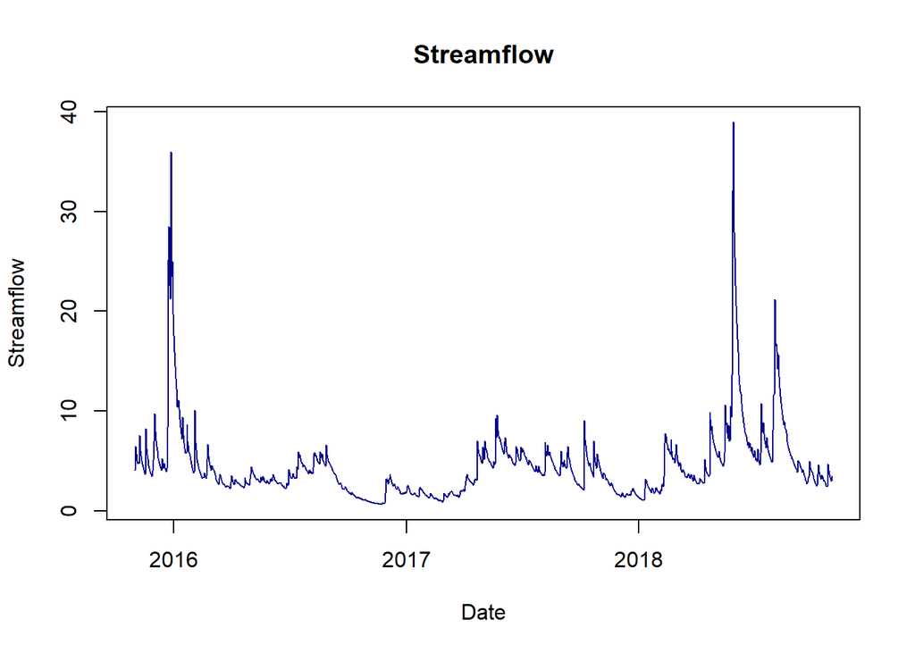

```r
plot(singleruntest$bd$streamflow~singleruntest$bd$date, type = "l", main = "Streamflow", xlab = "Date", ylab = "Streamflow", col = 'DarkBlue')
```

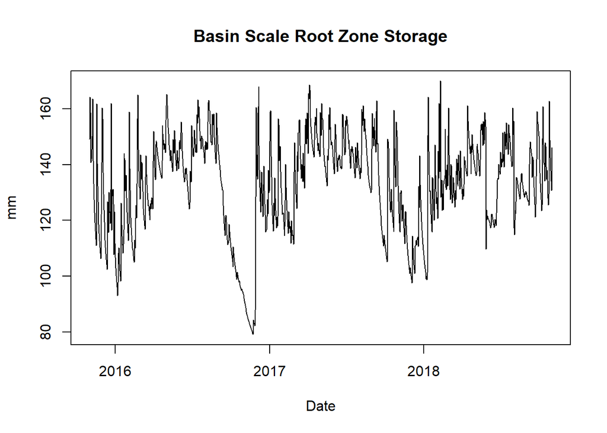

```r
plot(as.Date(singleruntest$bd$date),singleruntest$bd$rz_storage, type = "l", col = 'black', main = "Basin Scale Root Zone Storage",
    xlab = "Date", ylab = "mm")
```

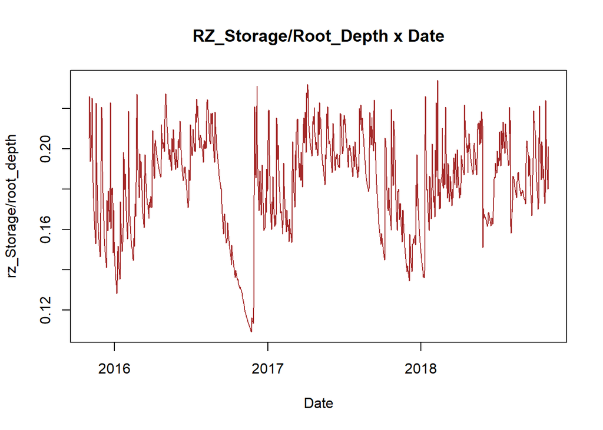

```r
#basin scale soil moisture
plot(singleruntest$bd$rz_storage/singleruntest$bd$rootdepth~singleruntest$bd$date, type = "l", main = "RZ_Storage/Root_Depth x Date", xlab = "Date", ylab = "rz_Storage/root_depth", col = 'brown')
```

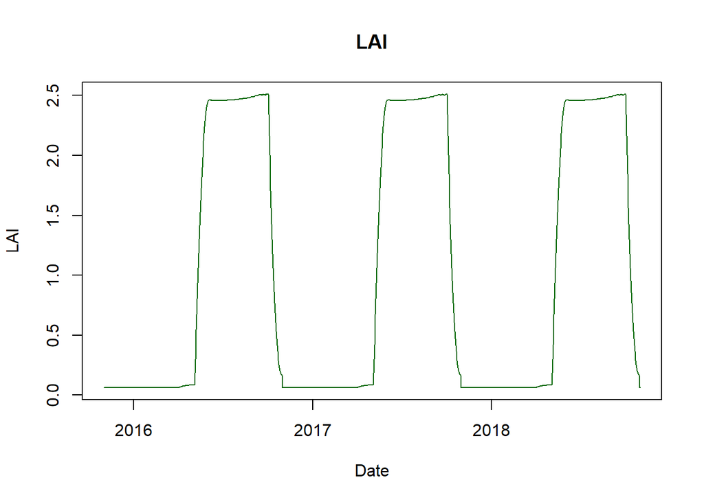

```r
plot(singleruntest$bd$lai~singleruntest$bd$date, type = "l", main = "LAI", xlab = "Date", ylab = "LAI", col = 'DarkGreen')
```

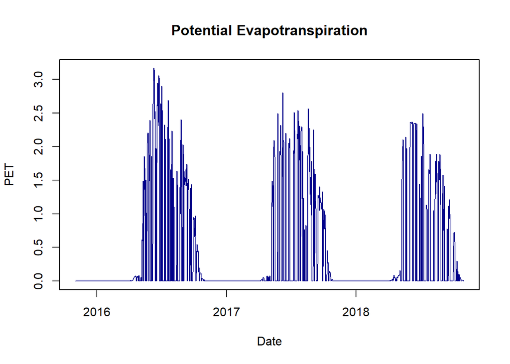

```r
plot(singleruntest$bd$pet~singleruntest$bd$date, type = "l", main = "Potential Evapotranspiration", xlab = "Date", ylab = "PET", col = 'DarkBlue')
```

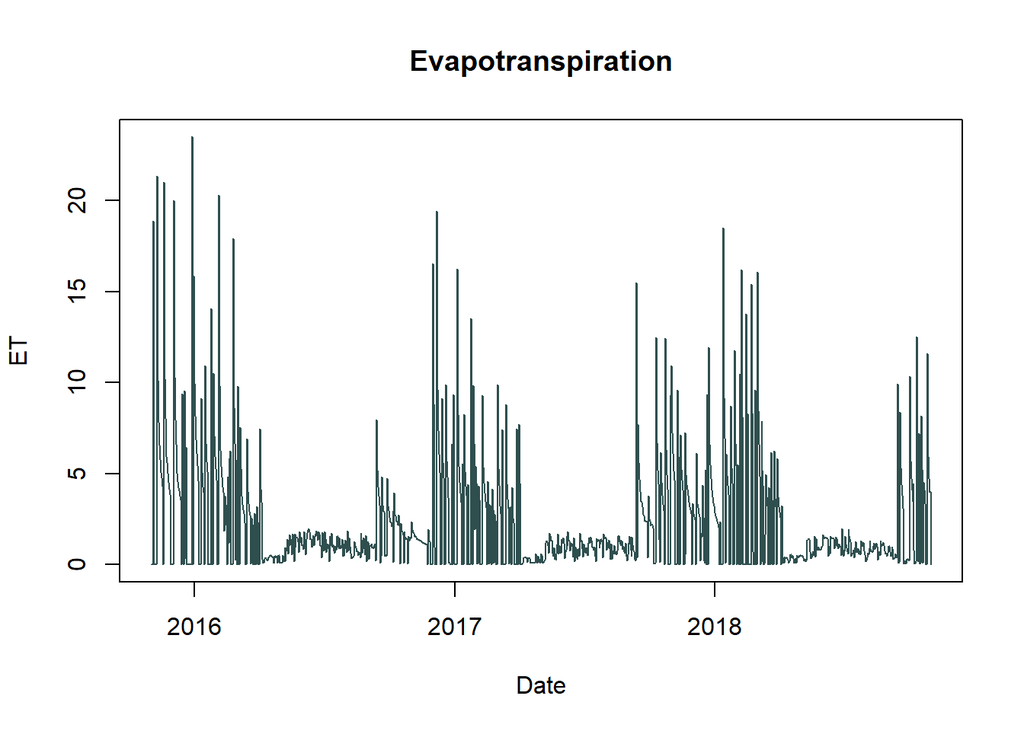

```r
plot(singleruntest$bd$et~singleruntest$bd$date, type = "l", main = "Evapotranspiration", xlab = "Date", ylab = "ET", col = 'darkslategray')
```

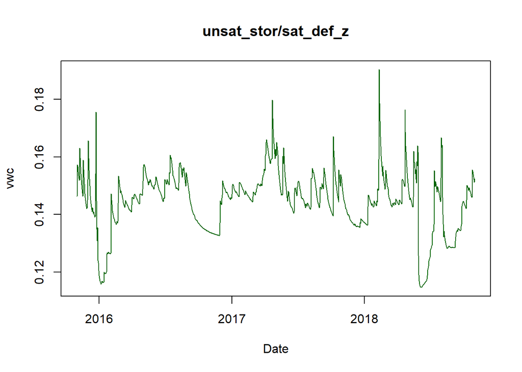

```r
plot((singleruntest$bd$unsat_stor/singleruntest$bd$sat_def_z)~singleruntest$bd$date, type = "l", main = "unsat_stor/sat_def_z", xlab = "Date", ylab = "vwc", col = 'DarkGreen')
```

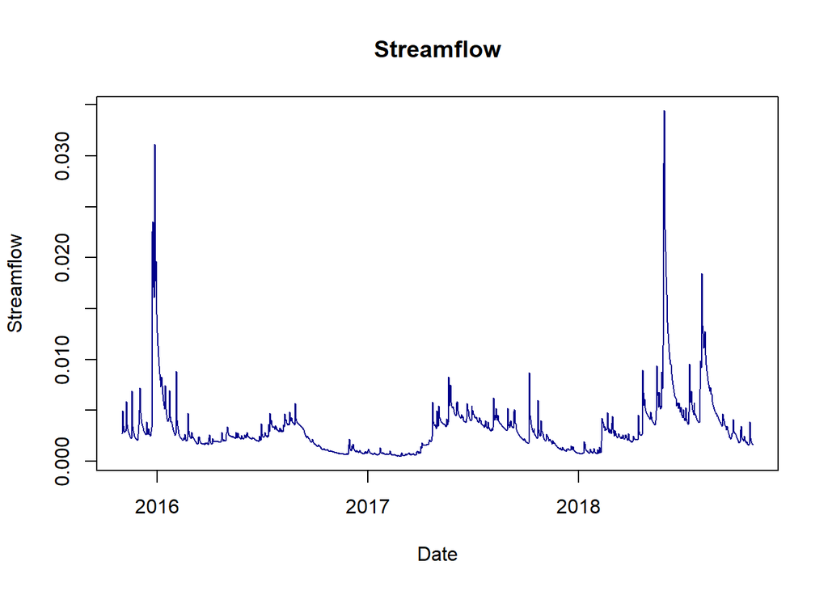

```r
setwd(system.file("extdata/", package = "RHESSysIOinR"))

singlerunfiltertest<- read_delim("outputfilter/ws32basin_daily_single.csv", delim = ",")

singlerunfiltertest$date<- as.Date(paste(singlerunfiltertest$day,singlerunfiltertest$month,singlerunfiltertest$year, sep = "/"),"%d/%m/%Y")

plot(singlerunfiltertest$streamflow~singlerunfiltertest$date, type = "l", main = "Streamflow", xlab = "Date", ylab = "Streamflow", col = 'DarkBlue')
```

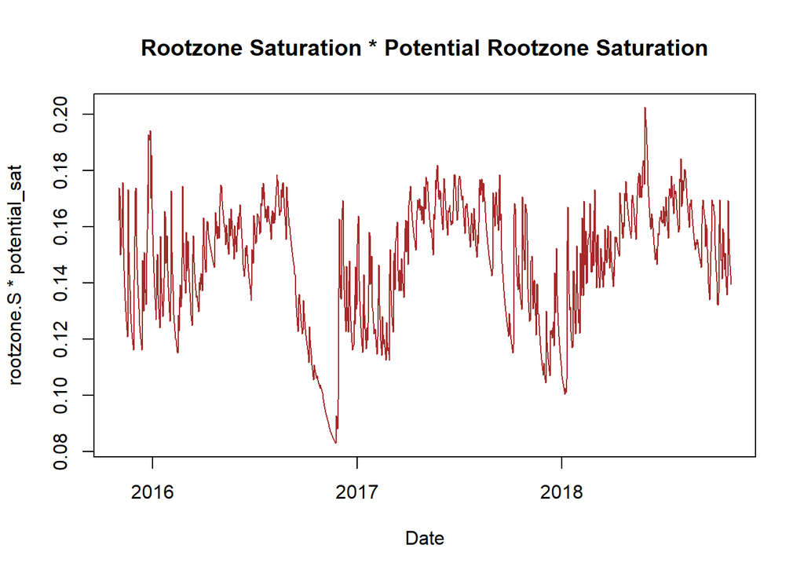

```r
#basin scale soil moisture
plot((singlerunfiltertest$rootzone.S*singlerunfiltertest$rootzone.potential_sat)~singlerunfiltertest$date, type = "l", main = "Rootzone Saturation * Potential Rootzone Saturation", xlab = "Date", ylab = "rootzone.S * potential_sat", col = 'brown')
```